# Results - report January

b s

2023-01-06

# Results: Study A

## Simulation design

In study A, only fixed slopes and random and fixed intercepts were simulated and analysed.

Study A followed a 4 × 2 × 3 × 4 × 3 factorial design (yielding 288 simulations in total):

- 4 missingness patterns:
  - data missing completely at random *(mcar)*
  - data missing in blocks of consecutive observations *(block)*
  - lowest (100%-compliance) observations set as missing
  - highest and lowest (100%-compliance)/2 observations set as missing
- 2 values of N (number of participants): 20, 100
- 3 values of T.obs (number of datapoints per participant): 20, 50, 100
- 4 values of compliance: 0.4, 0.6, 0.8, 1
- 3 values of real (simulated) fixed autoregressive effect: 0.3, 0.5, 0.7

## Outcome: Estimation precision

First, we conducted an ANOVA to assess which of the 5 manipulated factors have an effect on the estimation bias and whether there is an interaction between these effects. Given the large sample size and the fact that we were not testing any a priori hypotheses, we did not use p-values or significance thresholds for statistical inferences; instead, we used the effect size of 0.06 as a cut-off for partial omega squared of each of the effects.

```r
library(effectsize)
library(ggplot2)
library(tidyverse)

rdslist = list.files(path = here::here("results", "sim_a_norandomslopes"), pattern='*.rds') # put all the data files with results in a list


anova_bias_df = data.frame(matrix(ncol = 7))
colnames(anova_bias_df) = c("B1_bias", "B1_sim", "N", "T.obs", "miss_type", "compliance", "model_observations")

for (i in 1:length(rdslist)){ # for-loop that connects all files from rdslist into one file
  res = readRDS(here::here("results", "sim_a_norandomslopes", rdslist[i]))
  B1_bias = res$beta.hat.lme.list[, 2] - res$b10
  B1_sim = res$b10
  N = res$N
  T.obs = res$T.obs
  miss_type = res$missing_type
  compliance = res$comp_mean
  model_observations = res$model_observations
  results = data.frame(B1_bias, B1_sim, N, T.obs, miss_type, compliance, model_observations)

  anova_bias_df = rbind(anova_bias_df, results)
}

# for some reason, the first row is only NAs, remove it:
anova_bias_df = anova_bias_df[-1, ]
```

### Estimation precision ANOVA results

```r
anova_bias = aov(formula = B1_bias ~ N * T.obs * miss_type * compliance * B1_sim,
                 data = anova_bias_df)

(anova_bias_results = summary(anova_bias))
```

```
##                                         Df Sum Sq Mean Sq   F value   Pr(>F)
## N                                        1    0.2     0.2 6.811e+01  < 2e-16
## T.obs                                    1  356.4   356.4 1.167e+05  < 2e-16
## miss_type                                3 2653.4   884.5 2.896e+05  < 2e-16
## compliance                               1 1714.6  1714.6 5.614e+05  < 2e-16
## B1_sim                                   1  162.3   162.3 5.313e+04  < 2e-16
## N:T.obs                                  1    0.0     0.0 9.623e+00  0.00192
## N:miss_type                              3    0.1     0.0 9.764e+00 1.95e-06
## T.obs:miss_type                          3   14.2     4.7 1.548e+03  < 2e-16
## N:compliance                             1    0.2     0.2 5.021e+01 1.38e-12
## T.obs:compliance                         1   23.7    23.7 7.765e+03  < 2e-16
## miss_type:compliance                     3 1154.7   384.9 1.260e+05  < 2e-16
## N:B1_sim                                 1    0.1     0.1 3.757e+01 8.83e-10
## T.obs:B1_sim                             1    2.2     2.2 7.353e+02  < 2e-16
## miss_type:B1_sim                         3  145.9    48.6 1.592e+04  < 2e-16
## compliance:B1_sim                        1   61.7    61.7 2.019e+04  < 2e-16
## N:T.obs:miss_type                        3    0.0     0.0 5.117e+00  0.00154
## N:T.obs:compliance                       1    0.0     0.0 1.008e+01  0.00150
## N:miss_type:compliance                   3    0.1     0.0 1.325e+01 1.21e-08
## T.obs:miss_type:compliance               3    8.6     2.9 9.340e+02  < 2e-16
## N:T.obs:B1_sim                           1    0.1     0.1 2.532e+01 4.86e-07
## N:miss_type:B1_sim                       3    0.1     0.0 1.461e+01 1.65e-09
## T.obs:miss_type:B1_sim                   3    3.6     1.2 3.897e+02  < 2e-16
## N:compliance:B1_sim                      1    0.1     0.1 4.857e+01 3.19e-12
## T.obs:compliance:B1_sim                  1    0.1     0.1 4.230e+01 7.86e-11
## miss_type:compliance:B1_sim              3   93.8    31.3 1.024e+04  < 2e-16
## N:T.obs:miss_type:compliance             3    0.0     0.0 4.207e+00  0.00553
## N:T.obs:miss_type:B1_sim                 3    0.0     0.0 1.571e+00  0.19402
## N:T.obs:compliance:B1_sim                1    0.0     0.0 8.537e+00  0.00348
## N:miss_type:compliance:B1_sim            3    0.0     0.0 7.790e-01  0.50526
## T.obs:miss_type:compliance:B1_sim        3    2.9     1.0 3.212e+02  < 2e-16
## N:T.obs:miss_type:compliance:B1_sim      3    0.0     0.0 1.506e+00  0.21079
## Residuals                           285936  873.2     0.0
##
## N                                   ***
## T.obs                               ***
## miss_type                           ***
## compliance                          ***
## B1_sim                              ***
## N:T.obs                             **
```

[output cut: 13 more lines]

```
## N:T.obs:B1_sim                      ***
## N:miss_type:B1_sim                  ***
## T.obs:miss_type:B1_sim              ***
## N:compliance:B1_sim                 ***
## T.obs:compliance:B1_sim             ***
## miss_type:compliance:B1_sim         ***
## N:T.obs:miss_type:compliance        **
## N:T.obs:miss_type:B1_sim
## N:T.obs:compliance:B1_sim           **
## N:miss_type:compliance:B1_sim
## T.obs:miss_type:compliance:B1_sim   ***
## N:T.obs:miss_type:compliance:B1_sim
## Residuals
## ---
## Signif. codes:  0 '***' 0.001 '**' 0.01 '*' 0.05 '.' 0.1 ' ' 1
```

### Estimation precision ANOVA effect sizes

```r
omega_squared(anova_bias, partial = TRUE)
```

| Parameter | Omega2_partial | CI | CI_low | CI_high |
| --- | --- | --- | --- | --- |
| N | 0.0002346 | 0.95 | 0.0001498 | 1 |
| T.obs | 0.2897944 | 0.95 | 0.3097961 | 1 |
| miss_type | 0.7523453 | 0.95 | 0.7696738 | 1 |
| compliance | 0.6625099 | 0.95 | 0.6834796 | 1 |
| B1_sim | 0.1566637 | 0.95 | 0.1696720 | 1 |
| N:T.obs | 0.0000301 | 0.95 | 0.0000058 | 1 |
| N:miss_type | 0.0000919 | 0.95 | 0.0000366 | 1 |
| T.obs:miss_type | 0.0159634 | 0.95 | 0.0152035 | 1 |
| N:compliance | 0.0001720 | 0.95 | 0.0001008 | 1 |
| T.obs:compliance | 0.0264310 | 0.95 | 0.0254718 | 1 |
| miss_type:compliance | 0.5693408 | 0.95 | 0.5925392 | 1 |
| N:B1_sim | 0.0001278 | 0.95 | 0.0000678 | 1 |
| T.obs:B1_sim | 0.0025608 | 0.95 | 0.0022598 | 1 |
| miss_type:B1_sim | 0.1431139 | 0.95 | 0.1552041 | 1 |
| compliance:B1_sim | 0.0659455 | 0.95 | 0.0720649 | 1 |
| N:T.obs:miss_type | 0.0000432 | 0.95 | 0.0000071 | 1 |
| N:T.obs:compliance | 0.0000317 | 0.95 | 0.0000065 | 1 |
| N:miss_type:compliance | 0.0001284 | 0.95 | 0.0000622 | 1 |
| T.obs:miss_type:compliance | 0.0096921 | 0.95 | 0.0090960 | 1 |
| N:T.obs:B1_sim | 0.0000850 | 0.95 | 0.0000378 | 1 |
| N:miss_type:B1_sim | 0.0001427 | 0.95 | 0.0000727 | 1 |
| T.obs:miss_type:B1_sim | 0.0040605 | 0.95 | 0.0036729 | 1 |
| N:compliance:B1_sim | 0.0001663 | 0.95 | 0.0000964 | 1 |
| T.obs:compliance:B1_sim | 0.0001444 | 0.95 | 0.0000799 | 1 |
| miss_type:compliance:B1_sim | 0.0969452 | 0.95 | 0.1056159 | 1 |
| N:T.obs:miss_type:compliance | 0.0000336 | 0.95 | 0.0000026 | 1 |
| N:T.obs:miss_type:B1_sim | 0.0000060 | 0.95 | 0.0000000 | 1 |
| N:T.obs:compliance:B1_sim | 0.0000264 | 0.95 | 0.0000042 | 1 |
| N:miss_type:compliance:B1_sim | 0.0000000 | 0.95 | 0.0000000 | 1 |
| T.obs:miss_type:compliance:B1_sim | 0.0033479 | 0.95 | 0.0029959 | 1 |
| N:T.obs:miss_type:compliance:B1_sim | 0.0000053 | 0.95 | 0.0000000 | 1 |

The only manipulated parameter that seems to not influence estimation precision is the number of participants. Meanwhile missingness type, compliance, number of observations per participant and the true fixed AR effect value all appear to have an influence on the estimation precision.

*note: I use causal language here (“have an influence on”) - is that a correct thing to do (given that the simulation is basically an experiment), or should I stay with “is associated with”?*

### Estimation precision: mean comparisons

- TODO: what cutoff do we use here? do we even want to run

#### Missingness type

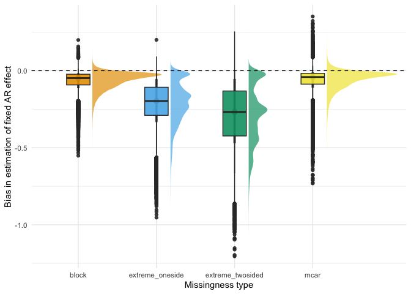

```r
library(ggdist)
# set a colorblind-friendly color pallete
cbPalette = c("#E69F00", "#56B4E9", "#009E73", "#F0E442", "#0072B2", "#D55E00", "#CC79A7", "#000000")

cbPalette_other = c("#0072B2", "#D55E00", "#CC79A7", "#000000")



(boxplot_precision_type = anova_bias_df %>%
  ggplot(aes(x = as.factor(miss_type), y = B1_bias, fill = as.factor(miss_type), group = as.factor(miss_type))) +
  stat_halfeye(justification = -0.2, alpha = 0.7, outlier.size = 1) +
  geom_boxplot(width = 0.3, alpha = 0.9) +
  theme_minimal() +
  scale_fill_manual(values = cbPalette) +
  ylab("Bias in estimation of fixed AR effect") +
  xlab("Missingness type") +
  theme(legend.position = "none") +
  geom_hline(yintercept = 0, linetype = "dashed")
  )
```

Why are the distributions kind-of normal for block and mcar, but tri-modal in the ‘extreme’ conditions? In my opinion, it’s because the bias is (more) dependent on the true effect size in the extreme conditions (the bigger the true AR, the bigger the bias), which causes 3 different values of bias (because we simulated 3 values of true AR)

#### Compliance

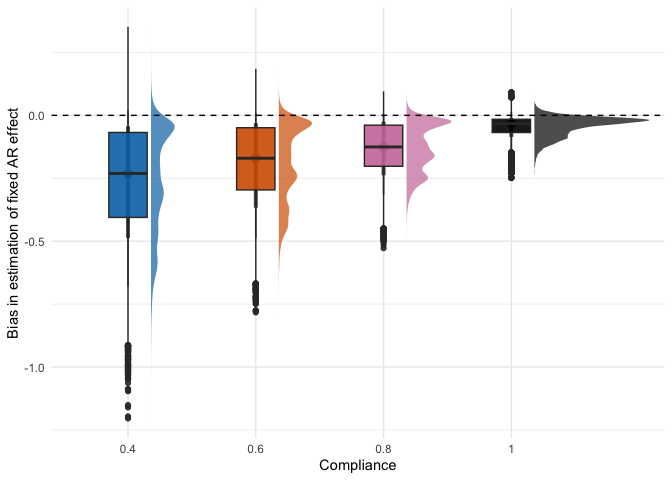

```r
(boxplot_precision_compliance = anova_bias_df %>%
  ggplot(aes(x = as.factor(compliance), y = B1_bias, fill = as.factor(compliance), group = as.factor(compliance))) +
  stat_halfeye(justification = -0.2, alpha = 0.7, outlier.size = 1) +
  geom_boxplot(width = 0.3, alpha = 0.9) +
  theme_minimal() +
  scale_fill_manual(values = cbPalette_other) +
  ylab("Bias in estimation of fixed AR effect") +
  xlab("Compliance") +
  theme(legend.position = "none") +
  geom_hline(yintercept = 0, linetype = "dashed")
  )
```

#### Number of timepoints per participant

The effect of the number of timepoints per participant on estimation bias (averaged over the other manipulated parameters)

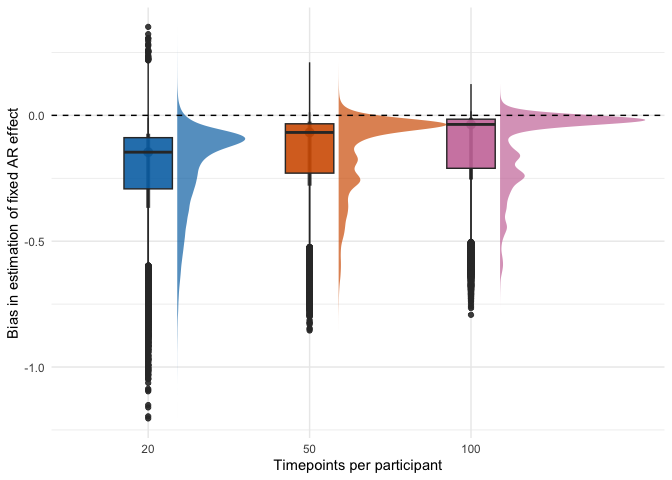

```r
(boxplot_precision_t = anova_bias_df %>%
  ggplot(aes(x = as.factor(T.obs), y = B1_bias, fill = as.factor(T.obs), group = as.factor(T.obs))) +
  stat_halfeye(justification = -0.2, alpha = 0.7, outlier.size = 1) +
  geom_boxplot(width = 0.3, alpha = 0.9) +
  theme_minimal() +
  scale_fill_manual(values = cbPalette_other) +
  ylab("Bias in estimation of fixed AR effect") +
  xlab("Timepoints per participant") +
  geom_hline(yintercept = 0, linetype = "dashed") +
  theme(legend.position = "none")
  )
```

#### Real fixed AR effect

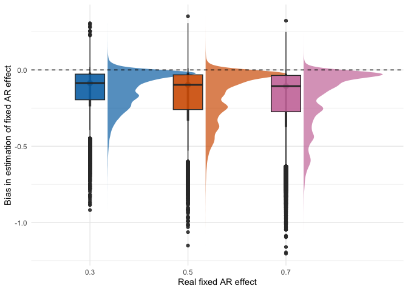

```r
(boxplot_precision_ar = anova_bias_df %>%
  ggplot(aes(x = as.factor(B1_sim), y = B1_bias, fill = as.factor(B1_sim), group = as.factor(B1_sim))) +
  stat_halfeye(justification = -0.2, alpha = 0.7, outlier.size = 1) +
  geom_boxplot(width = 0.3, alpha = 0.9) +
  theme_minimal() +
  scale_fill_manual(values = cbPalette_other) +
  ylab("Bias in estimation of fixed AR effect") +
  xlab("Real fixed AR effect") +
  geom_hline(yintercept = 0, linetype = "dashed") +
  theme(legend.position = "none")
  )
```

### Interactions

#### Number of timepoints per participant * Missingness type

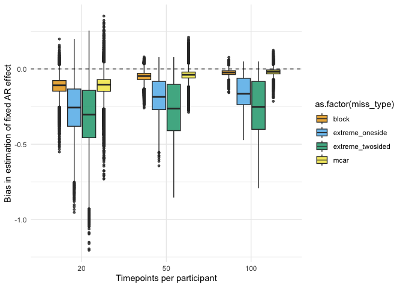

```r
(boxplot_precision_t_misstype = anova_bias_df %>%
  ggplot(aes(x = as.factor(T.obs), y = B1_bias, fill = as.factor(miss_type))) +
  geom_boxplot(width = 0.7, alpha = 0.8, outlier.size = 1) +
  theme_minimal() +
  scale_fill_manual(values = cbPalette) +
  ylab("Bias in estimation of fixed AR effect") +
  xlab("Timepoints per participant") +
  geom_hline(yintercept = 0, linetype = "dashed"))
```

#### Missingness type * True fixed AR effect

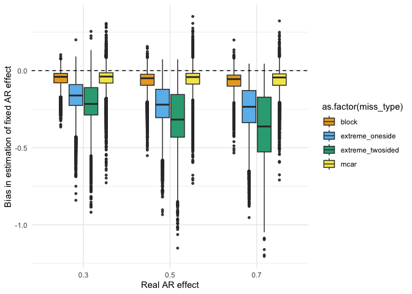

```r
(boxplot_precision_ar_misstype = anova_bias_df %>%
  ggplot(aes(x = as.factor(B1_sim), y = B1_bias, fill = as.factor(miss_type))) +
  geom_boxplot(width = 0.7, alpha = 0.9, outlier.size = 1) +
  theme_minimal() +
  scale_fill_manual(values = cbPalette) +
  ylab("Bias in estimation of fixed AR effect") +
  xlab("Real AR effect") +
  geom_hline(yintercept = 0, linetype = "dashed")
  )
```

#### Compliance * True fixed AR effect

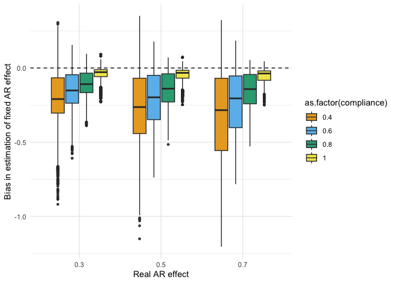

```r
(boxplot_precision_ar_compliance = anova_bias_df %>%
  ggplot(aes(x = as.factor(B1_sim), y = B1_bias, fill = as.factor(compliance)))) +
  geom_boxplot(width = 0.7, alpha = 0.9, outlier.size = 1) +
  theme_minimal() +
  scale_fill_manual(values = cbPalette) +
  ylab("Bias in estimation of fixed AR effect") +
  xlab("Real AR effect") +
  geom_hline(yintercept = 0, linetype = "dashed")
```

#### Compliance * Missingness type

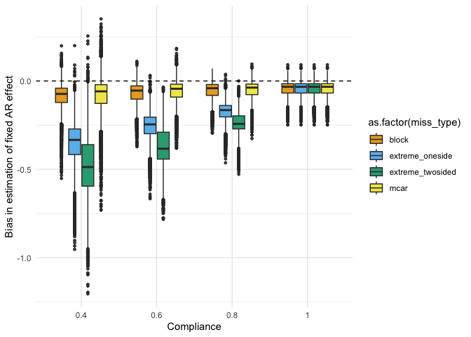

```r
(boxplot_precision_compliance_misstype = anova_bias_df %>%
  ggplot(aes(x = as.factor(compliance), y = B1_bias, fill = as.factor(miss_type))) +
  geom_boxplot(width = 0.7, alpha = 0.9, outlier.size = 1) +
  theme_minimal() +
  scale_fill_manual(values = cbPalette) +
  ylab("Bias in estimation of fixed AR effect") +
  xlab("Compliance") +
  geom_hline(yintercept = 0, linetype = "dashed"))
```

## Outcome: MSE

### MSE ANOVA

```r
anova_mse = aov(formula = B1_se ~ N * T.obs * miss_type * comp_mean * B1_sim,
                 data = overall_df)

(anova_mse_results = summary(anova_mse))
```

```
##                                     Df  Sum Sq Mean Sq F value   Pr(>F)
## N                                    1 0.05826 0.05826 596.729  < 2e-16 ***
## T.obs                                1 0.05835 0.05835 597.660  < 2e-16 ***
## miss_type                            3 0.00469 0.00156  16.024 1.83e-09 ***
## comp_mean                            1 0.05240 0.05240 536.727  < 2e-16 ***
## B1_sim                               1 0.00201 0.00201  20.551 9.49e-06 ***
## N:T.obs                              1 0.00862 0.00862  88.304  < 2e-16 ***
## N:miss_type                          3 0.00064 0.00021   2.200   0.0889 .
## T.obs:miss_type                      3 0.00052 0.00017   1.769   0.1539
## N:comp_mean                          1 0.00796 0.00796  81.483  < 2e-16 ***
## T.obs:comp_mean                      1 0.01086 0.01086 111.217  < 2e-16 ***
## miss_type:comp_mean                  3 0.00373 0.00124  12.736 1.04e-07 ***
## N:B1_sim                             1 0.00031 0.00031   3.127   0.0784 .
## T.obs:B1_sim                         1 0.00011 0.00011   1.151   0.2846
## miss_type:B1_sim                     3 0.00006 0.00002   0.200   0.8961
## comp_mean:B1_sim                     1 0.00016 0.00016   1.671   0.1975
## N:T.obs:miss_type                    3 0.00009 0.00003   0.293   0.8304
## N:T.obs:comp_mean                    1 0.00162 0.00162  16.570 6.52e-05 ***
## N:miss_type:comp_mean                3 0.00055 0.00018   1.872   0.1352
## T.obs:miss_type:comp_mean            3 0.00062 0.00021   2.119   0.0987 .
## N:T.obs:B1_sim                       1 0.00001 0.00001   0.104   0.7470
## N:miss_type:B1_sim                   3 0.00001 0.00000   0.028   0.9938
## T.obs:miss_type:B1_sim               3 0.00000 0.00000   0.008   0.9990
## N:comp_mean:B1_sim                   1 0.00002 0.00002   0.210   0.6472
## T.obs:comp_mean:B1_sim               1 0.00001 0.00001   0.075   0.7840
## miss_type:comp_mean:B1_sim           3 0.00003 0.00001   0.088   0.9665
## N:T.obs:miss_type:comp_mean          3 0.00013 0.00004   0.444   0.7215
## N:T.obs:miss_type:B1_sim             3 0.00000 0.00000   0.014   0.9977
## N:T.obs:comp_mean:B1_sim             1 0.00000 0.00000   0.001   0.9799
## N:miss_type:comp_mean:B1_sim         3 0.00001 0.00000   0.019   0.9964
## T.obs:miss_type:comp_mean:B1_sim     3 0.00001 0.00000   0.038   0.9899
## N:T.obs:miss_type:comp_mean:B1_sim   3 0.00001 0.00000   0.043   0.9882
## Residuals                          222 0.02168 0.00010
## ---
## Signif. codes:  0 '***' 0.001 '**' 0.01 '*' 0.05 '.' 0.1 ' ' 1
```

### MSE ANOVA effect sizes

```r
omega_squared(anova_mse, partial = TRUE)
```

| Parameter | Omega2_partial | CI | CI_low | CI_high |
| --- | --- | --- | --- | --- |
| N | 0.6756372 | 0.95 | 0.6226000 | 1 |
| T.obs | 0.6759795 | 0.95 | 0.6229892 | 1 |
| miss_type | 0.1361400 | 0.95 | 0.0669663 | 1 |
| comp_mean | 0.6519523 | 0.95 | 0.5957380 | 1 |
| B1_sim | 0.0639852 | 0.95 | 0.0216912 | 1 |
| N:T.obs | 0.2338676 | 0.95 | 0.1581412 | 1 |
| N:miss_type | 0.0124308 | 0.95 | 0.0000000 | 1 |
| T.obs:miss_type | 0.0080029 | 0.95 | 0.0000000 | 1 |
| N:comp_mean | 0.2196084 | 0.95 | 0.1451276 | 1 |
| T.obs:comp_mean | 0.2781740 | 0.95 | 0.1997438 | 1 |
| miss_type:comp_mean | 0.1096090 | 0.95 | 0.0463055 | 1 |
| N:B1_sim | 0.0073833 | 0.95 | 0.0000000 | 1 |
| T.obs:B1_sim | 0.0005263 | 0.95 | 0.0000000 | 1 |
| miss_type:B1_sim | 0.0000000 | 0.95 | 0.0000000 | 1 |
| comp_mean:B1_sim | 0.0023407 | 0.95 | 0.0000000 | 1 |
| N:T.obs:miss_type | 0.0000000 | 0.95 | 0.0000000 | 1 |
| N:T.obs:comp_mean | 0.0516304 | 0.95 | 0.0144724 | 1 |
| N:miss_type:comp_mean | 0.0090640 | 0.95 | 0.0000000 | 1 |
| T.obs:miss_type:comp_mean | 0.0116009 | 0.95 | 0.0000000 | 1 |
| N:T.obs:B1_sim | 0.0000000 | 0.95 | 0.0000000 | 1 |
| N:miss_type:B1_sim | 0.0000000 | 0.95 | 0.0000000 | 1 |
| T.obs:miss_type:B1_sim | 0.0000000 | 0.95 | 0.0000000 | 1 |
| N:comp_mean:B1_sim | 0.0000000 | 0.95 | 0.0000000 | 1 |
| T.obs:comp_mean:B1_sim | 0.0000000 | 0.95 | 0.0000000 | 1 |
| miss_type:comp_mean:B1_sim | 0.0000000 | 0.95 | 0.0000000 | 1 |
| N:T.obs:miss_type:comp_mean | 0.0000000 | 0.95 | 0.0000000 | 1 |
| N:T.obs:miss_type:B1_sim | 0.0000000 | 0.95 | 0.0000000 | 1 |
| N:T.obs:comp_mean:B1_sim | 0.0000000 | 0.95 | 0.0000000 | 1 |
| N:miss_type:comp_mean:B1_sim | 0.0000000 | 0.95 | 0.0000000 | 1 |
| T.obs:miss_type:comp_mean:B1_sim | 0.0000000 | 0.95 | 0.0000000 | 1 |
| N:T.obs:miss_type:comp_mean:B1_sim | 0.0000000 | 0.95 | 0.0000000 | 1 |

**Main effects**:

- Number of participants (partial ω2 = 0.67)
- Number of timepoints (partial ω2 = 0.67)
- Compliance (partial ω2 = 0.65)

**Interactions**:

- Time-series length and compliance (partial ω2 = 0.28)
- Number of participants and compliance (partial ω2 = 0.21)

### MSE: mean comparisons

#### Number of participants

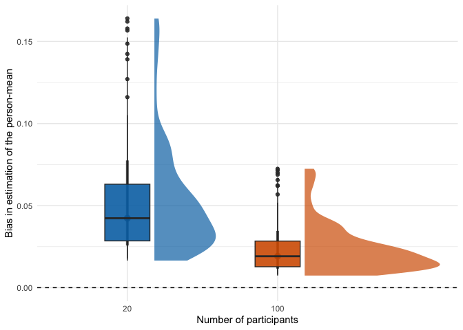

```r
(boxplot_mse_n = overall_df %>%
  ggplot(aes(x = as.factor(N), y = B1_se, fill = as.factor(N), group = as.factor(N))) +
  stat_halfeye(justification = -0.2, alpha = 0.7, outlier.size = 1) +
  geom_boxplot(width = 0.3, alpha = 0.9) +
  theme_minimal() +
  scale_fill_manual(values = cbPalette_other) +
  ylab("Bias in estimation of the person-mean") +
  xlab("Number of participants") +
  theme(legend.position = "none") +
  geom_hline(yintercept = 0, linetype = "dashed")
  )
```

#### Time-series length

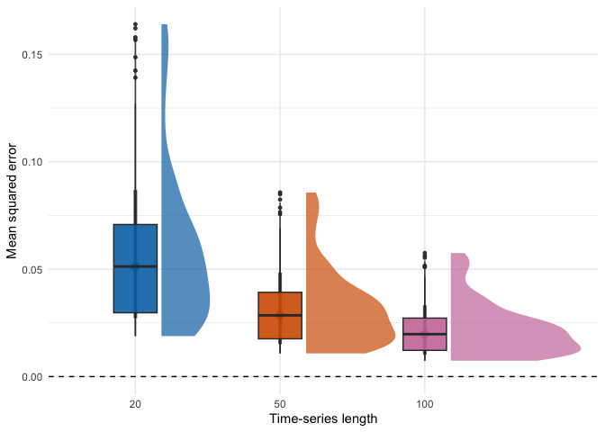

```r
(boxplot_mse_t = overall_df %>%
  ggplot(aes(x = as.factor(T.obs), y = B1_se, fill = as.factor(T.obs), group = as.factor(T.obs))) +
  stat_halfeye(justification = -0.2, alpha = 0.7) +
  geom_boxplot(width = 0.3, alpha = 0.9, outlier.size = 1) +
  theme_minimal() +
  scale_fill_manual(values = cbPalette_other) +
  ylab("Mean squared error") +
  xlab("Time-series length") +
  theme(legend.position = "none") +
  geom_hline(yintercept = 0, linetype = "dashed")
  )
```

#### Compliance

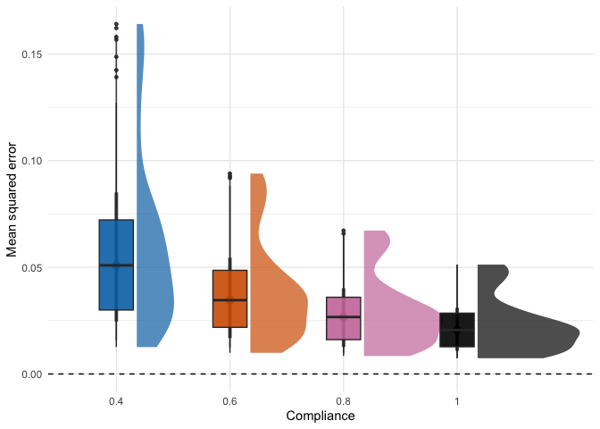

```r
(boxplot_mse_compliance = overall_df %>%
  ggplot(aes(x = as.factor(comp_mean), y = B1_se, fill = as.factor(comp_mean), group = as.factor(comp_mean))) +
  stat_halfeye(justification = -0.2, alpha = 0.7) +
  geom_boxplot(width = 0.3, alpha = 0.9, outlier.size = 1) +
  theme_minimal() +
  scale_fill_manual(values = cbPalette_other) +
  ylab("Mean squared error") +
  xlab("Compliance") +
  theme(legend.position = "none") +
  geom_hline(yintercept = 0, linetype = "dashed")
  )
```

#### Interaction: Time-series length and compliance

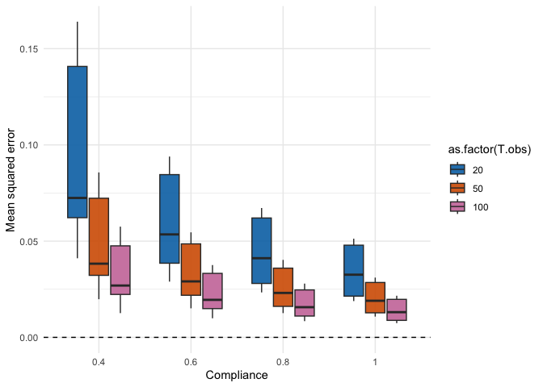

```r
(boxplot_mse_compliance_t = overall_df %>%
  ggplot(aes(x = as.factor(comp_mean), y = B1_se, fill = as.factor(T.obs))) +
  geom_boxplot(width = 0.7, alpha = 0.9, outlier.size = 1) +
  theme_minimal() +
  scale_fill_manual(values = cbPalette_other) +
  ylab("Mean squared error") +
  xlab("Compliance") +
  geom_hline(yintercept = 0, linetype = "dashed"))
```

#### Interaction: Number of participants and compliance

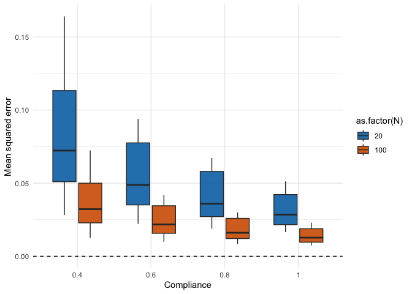

```r
(boxplot_mse_compliance_n = overall_df %>%
  ggplot(aes(x = as.factor(comp_mean), y = B1_se, fill = as.factor(N))) +
  geom_boxplot(width = 0.7, alpha = 0.9, outlier.size = 1) +
  theme_minimal() +
  scale_fill_manual(values = cbPalette_other) +
  ylab("Mean squared error") +
  xlab("Compliance") +
  geom_hline(yintercept = 0, linetype = "dashed"))
```

## Outcome: Statistical power

### Power ANOVA

```r
anova_power = aov(formula = B1_pow ~ N * T.obs * miss_type * comp_mean * B1_sim,
                 data = overall_df)

(anova_power_results = summary(anova_power))
```

```
##                                     Df Sum Sq Mean Sq F value   Pr(>F)
## N                                    1  0.381   0.381  20.351 1.04e-05 ***
## T.obs                                1  1.135   1.135  60.634 2.60e-13 ***
## miss_type                            3  3.465   1.155  61.684  < 2e-16 ***
## comp_mean                            1  4.326   4.326 231.039  < 2e-16 ***
## B1_sim                               1  1.326   1.326  70.806 4.85e-15 ***
## N:T.obs                              1  0.067   0.067   3.583 0.059664 .
## N:miss_type                          3  0.106   0.035   1.884 0.133185
## T.obs:miss_type                      3  0.371   0.124   6.602 0.000272 ***
## N:comp_mean                          1  0.216   0.216  11.528 0.000812 ***
## T.obs:comp_mean                      1  0.750   0.750  40.039 1.36e-09 ***
## miss_type:comp_mean                  3  3.160   1.053  56.260  < 2e-16 ***
## N:B1_sim                             1  0.076   0.076   4.070 0.044863 *
## T.obs:B1_sim                         1  0.207   0.207  11.061 0.001031 **
## miss_type:B1_sim                     3  0.472   0.157   8.399 2.60e-05 ***
## comp_mean:B1_sim                     1  0.725   0.725  38.714 2.42e-09 ***
## N:T.obs:miss_type                    3  0.013   0.004   0.239 0.869043
## N:T.obs:comp_mean                    1  0.006   0.006   0.311 0.577551
## N:miss_type:comp_mean                3  0.033   0.011   0.592 0.620965
## T.obs:miss_type:comp_mean            3  0.259   0.086   4.616 0.003736 **
## N:T.obs:B1_sim                       1  0.010   0.010   0.515 0.473935
## N:miss_type:B1_sim                   3  0.015   0.005   0.271 0.846130
## T.obs:miss_type:B1_sim               3  0.079   0.026   1.406 0.241900
## N:comp_mean:B1_sim                   1  0.002   0.002   0.105 0.745913
## T.obs:comp_mean:B1_sim               1  0.011   0.011   0.576 0.448701
## miss_type:comp_mean:B1_sim           3  0.164   0.055   2.920 0.034933 *
## N:T.obs:miss_type:comp_mean          3  0.047   0.016   0.844 0.471348
## N:T.obs:miss_type:B1_sim             3  0.022   0.007   0.397 0.755353
## N:T.obs:comp_mean:B1_sim             1  0.005   0.005   0.279 0.598114
## N:miss_type:comp_mean:B1_sim         3  0.058   0.019   1.024 0.382707
## T.obs:miss_type:comp_mean:B1_sim     3  0.246   0.082   4.385 0.005072 **
## N:T.obs:miss_type:comp_mean:B1_sim   3  0.067   0.022   1.196 0.312179
## Residuals                          222  4.157   0.019
## ---
## Signif. codes:  0 '***' 0.001 '**' 0.01 '*' 0.05 '.' 0.1 ' ' 1
```

### Power ANOVA effect sizes

```r
omega_squared(anova_power, partial = TRUE)
```

| Parameter | Omega2_partial | CI | CI_low | CI_high |
| --- | --- | --- | --- | --- |
| N | 0.0633721 | 0.95 | 0.0213163 | 1 |
| T.obs | 0.1725360 | 0.95 | 0.1036997 | 1 |
| miss_type | 0.3889584 | 0.95 | 0.3059943 | 1 |
| comp_mean | 0.4457784 | 0.95 | 0.3693574 | 1 |
| B1_sim | 0.1961919 | 0.95 | 0.1242054 | 1 |
| N:T.obs | 0.0089517 | 0.95 | 0.0000000 | 1 |
| N:miss_type | 0.0091846 | 0.95 | 0.0000000 | 1 |
| T.obs:miss_type | 0.0554964 | 0.95 | 0.0101576 | 1 |
| N:comp_mean | 0.0355038 | 0.95 | 0.0063945 | 1 |
| T.obs:comp_mean | 0.1201065 | 0.95 | 0.0610386 | 1 |
| miss_type:comp_mean | 0.3669490 | 0.95 | 0.2832215 | 1 |
| N:B1_sim | 0.0106192 | 0.95 | 0.0000000 | 1 |
| T.obs:B1_sim | 0.0339844 | 0.95 | 0.0057369 | 1 |
| miss_type:B1_sim | 0.0720184 | 0.95 | 0.0200426 | 1 |
| comp_mean:B1_sim | 0.1165028 | 0.95 | 0.0582780 | 1 |
| N:T.obs:miss_type | 0.0000000 | 0.95 | 0.0000000 | 1 |
| N:T.obs:comp_mean | 0.0000000 | 0.95 | 0.0000000 | 1 |
| N:miss_type:comp_mean | 0.0000000 | 0.95 | 0.0000000 | 1 |
| T.obs:miss_type:comp_mean | 0.0365405 | 0.95 | 0.0008374 | 1 |
| N:T.obs:B1_sim | 0.0000000 | 0.95 | 0.0000000 | 1 |
| N:miss_type:B1_sim | 0.0000000 | 0.95 | 0.0000000 | 1 |
| T.obs:miss_type:B1_sim | 0.0042402 | 0.95 | 0.0000000 | 1 |
| N:comp_mean:B1_sim | 0.0000000 | 0.95 | 0.0000000 | 1 |
| T.obs:comp_mean:B1_sim | 0.0000000 | 0.95 | 0.0000000 | 1 |
| miss_type:comp_mean:B1_sim | 0.0197435 | 0.95 | 0.0000000 | 1 |
| N:T.obs:miss_type:comp_mean | 0.0000000 | 0.95 | 0.0000000 | 1 |
| N:T.obs:miss_type:B1_sim | 0.0000000 | 0.95 | 0.0000000 | 1 |
| N:T.obs:comp_mean:B1_sim | 0.0000000 | 0.95 | 0.0000000 | 1 |
| N:miss_type:comp_mean:B1_sim | 0.0002539 | 0.95 | 0.0000000 | 1 |
| T.obs:miss_type:comp_mean:B1_sim | 0.0342863 | 0.95 | 0.0000000 | 1 |
| N:T.obs:miss_type:comp_mean:B1_sim | 0.0020506 | 0.95 | 0.0000000 | 1 |

**Main effects:**

**Interactions:**

### Power: mean comparisons

#### Compliance

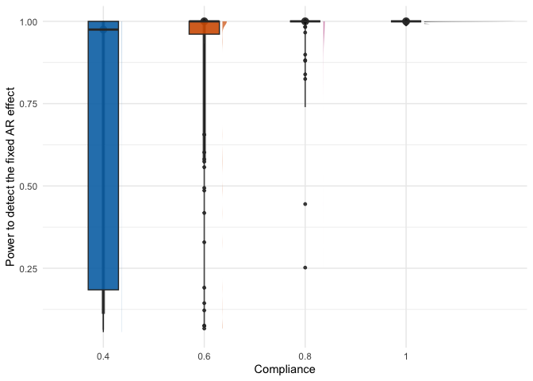

```r
(boxplot_power_compliance = overall_df %>%
  ggplot(aes(x = as.factor(comp_mean), y = B1_pow, fill = as.factor(comp_mean), group = as.factor(comp_mean))) +
  stat_halfeye(justification = -0.2, alpha = 0.7) +
  geom_boxplot(width = 0.3, alpha = 0.9, outlier.size = 1) +
  theme_minimal() +
  scale_fill_manual(values = cbPalette_other) +
  ylab("Power to detect the fixed AR effect") +
  xlab("Compliance") +
  theme(legend.position = "none")
  )
```

#### Missingness type

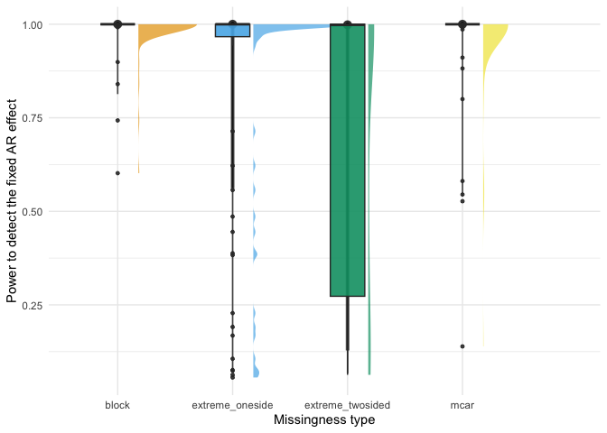

```r
(boxplot_power_miss_type = overall_df %>%
  ggplot(aes(x = as.factor(miss_type), y = B1_pow, fill = as.factor(miss_type), group = as.factor(miss_type))) +
  stat_halfeye(justification = -0.2, alpha = 0.7) +
  geom_boxplot(width = 0.3, alpha = 0.9, outlier.size = 1) +
  theme_minimal() +
  scale_fill_manual(values = cbPalette) +
  ylab("Power to detect the fixed AR effect") +
  xlab("Missingness type") +
  theme(legend.position = "none")
  )
```

#### Simulated fixed AR effect

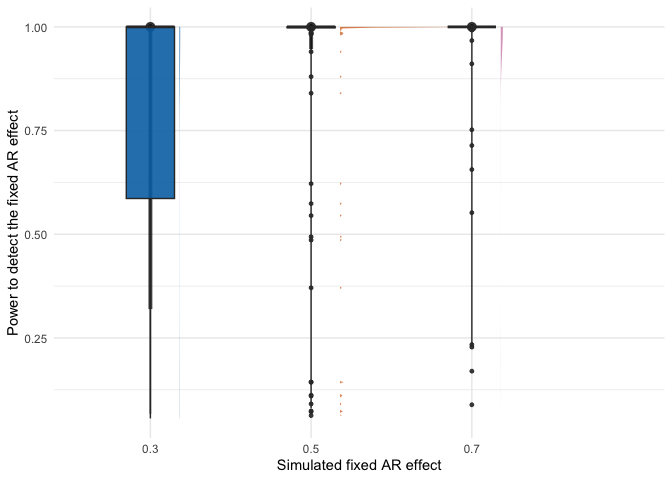

```r
(boxplot_power_ar = overall_df %>%
  ggplot(aes(x = as.factor(B1_sim), y = B1_pow, fill = as.factor(B1_sim), group = as.factor(B1_sim))) +
  stat_halfeye(justification = -0.2, alpha = 0.7) +
  geom_boxplot(width = 0.3, alpha = 0.9, outlier.size = 1) +
  theme_minimal() +
  scale_fill_manual(values = cbPalette_other) +
  ylab("Power to detect the fixed AR effect") +
  xlab("Simulated fixed AR effect") +
  theme(legend.position = "none")
  )
```

#### Number of timepoints

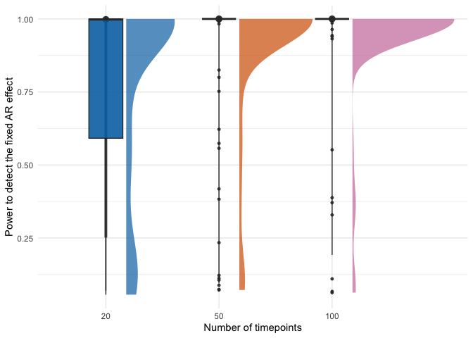

```r
(boxplot_power_t = overall_df %>%
  ggplot(aes(x = as.factor(T.obs), y = B1_pow, fill = as.factor(T.obs), group = as.factor(T.obs))) +
  stat_halfeye(justification = -0.2, alpha = 0.7) +
  geom_boxplot(width = 0.3, alpha = 0.9, outlier.size = 1) +
  theme_minimal() +
  scale_fill_manual(values = cbPalette_other) +
  ylab("Power to detect the fixed AR effect") +
  xlab("Number of timepoints") +
  theme(legend.position = "none")
  )
```

#### Interaction: Missingness type and compliance

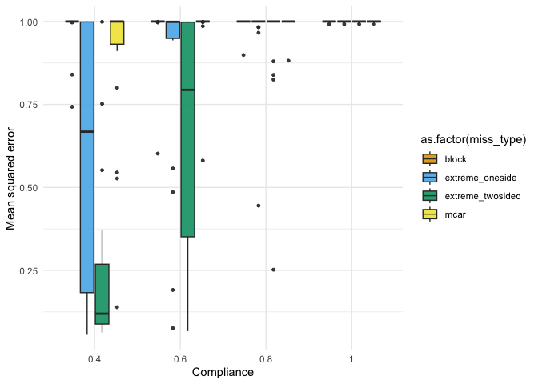

```r
(boxplot_power_compliance_miss_type = overall_df %>%
  ggplot(aes(x = as.factor(comp_mean), y = B1_pow, fill = as.factor(miss_type))) +
  geom_boxplot(width = 0.7, alpha = 0.9, outlier.size = 1) +
  theme_minimal() +
  scale_fill_manual(values = cbPalette) +
  ylab("Mean squared error") +
  xlab("Compliance") )
```

Interestingly, the effect of compliance and missingness type is much larger than the effect of the number of timepoints / participants.

## Outcome: Bias in person-mean estimation

### Bias in AR effect estimation and bias in person-mean estimation

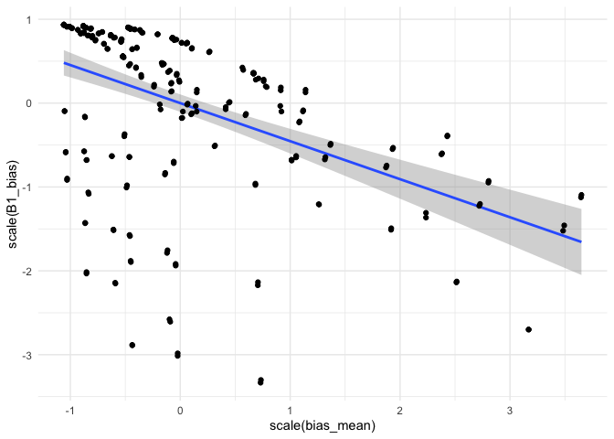

```r
overall_df %>%
  ggplot(aes(x = scale(bias_mean), y = scale(B1_bias))) +
  geom_smooth(method = 'lm') +
  geom_point() + theme_minimal()
```

```r
summary(lm(B1_bias~bias_mean, data = overall_df))
```

```
##
## Call:
## lm(formula = B1_bias ~ bias_mean, data = overall_df)
##
## Residuals:
##      Min       1Q   Median       3Q      Max
## -0.46794 -0.02358  0.06015  0.07879  0.11351
##
## Coefficients:
##             Estimate Std. Error t value Pr(>|t|)
## (Intercept) -0.05072    0.01449  -3.499 0.000541 ***
## bias_mean   -0.15624    0.01822  -8.578 6.39e-16 ***
## ---
## Signif. codes:  0 '***' 0.001 '**' 0.01 '*' 0.05 '.' 0.1 ' ' 1
##
## Residual standard error: 0.1354 on 284 degrees of freedom
## Multiple R-squared:  0.2058, Adjusted R-squared:  0.203
## F-statistic: 73.58 on 1 and 284 DF,  p-value: 6.386e-16
```

### Person-mean bias ANOVA

```r
anova_personmean = aov(formula = bias_mean ~ N * T.obs * miss_type * comp_mean * B1_sim,
                 data = overall_df)

(anova_personmean_results = summary(anova_personmean))
```

```
##                                     Df Sum Sq Mean Sq  F value   Pr(>F)
## N                                    1  0.000   0.000    0.009    0.926
## T.obs                                1  4.070   4.070  646.372  < 2e-16 ***
## miss_type                            3 19.578   6.526 1036.565  < 2e-16 ***
## comp_mean                            1  7.951   7.951 1262.849  < 2e-16 ***
## B1_sim                               1  7.004   7.004 1112.401  < 2e-16 ***
## N:T.obs                              1  0.000   0.000    0.001    0.978
## N:miss_type                          3  0.001   0.000    0.033    0.992
## T.obs:miss_type                      3  0.747   0.249   39.555  < 2e-16 ***
## N:comp_mean                          1  0.001   0.001    0.090    0.764
## T.obs:comp_mean                      1  0.041   0.041    6.575    0.011 *
## miss_type:comp_mean                  3 13.651   4.550  722.715  < 2e-16 ***
## N:B1_sim                             1  0.000   0.000    0.000    0.996
## T.obs:B1_sim                         1  0.322   0.322   51.075 1.27e-11 ***
## miss_type:B1_sim                     3  0.013   0.004    0.673    0.570
## comp_mean:B1_sim                     1  0.012   0.012    1.911    0.168
## N:T.obs:miss_type                    3  0.000   0.000    0.012    0.998
## N:T.obs:comp_mean                    1  0.000   0.000    0.019    0.890
## N:miss_type:comp_mean                3  0.000   0.000    0.019    0.996
## T.obs:miss_type:comp_mean            3  0.342   0.114   18.082 1.56e-10 ***
## N:T.obs:B1_sim                       1  0.000   0.000    0.010    0.920
## N:miss_type:B1_sim                   3  0.000   0.000    0.007    0.999
## T.obs:miss_type:B1_sim               3  0.032   0.011    1.695    0.169
## N:comp_mean:B1_sim                   1  0.000   0.000    0.016    0.899
## T.obs:comp_mean:B1_sim               1  0.018   0.018    2.936    0.088 .
## miss_type:comp_mean:B1_sim           3  0.019   0.006    0.984    0.401
## N:T.obs:miss_type:comp_mean          3  0.000   0.000    0.017    0.997
## N:T.obs:miss_type:B1_sim             3  0.000   0.000    0.015    0.997
## N:T.obs:comp_mean:B1_sim             1  0.000   0.000    0.028    0.868
## N:miss_type:comp_mean:B1_sim         3  0.000   0.000    0.026    0.994
## T.obs:miss_type:comp_mean:B1_sim     3  0.028   0.009    1.467    0.224
## N:T.obs:miss_type:comp_mean:B1_sim   3  0.001   0.000    0.041    0.989
## Residuals                          222  1.398   0.006
## ---
## Signif. codes:  0 '***' 0.001 '**' 0.01 '*' 0.05 '.' 0.1 ' ' 1
```

### Person-mean bias ANOVA effect sizes

```r
omega_squared(anova_personmean, partial = TRUE)
```

| Parameter | Omega2_partial | CI | CI_low | CI_high |
| --- | --- | --- | --- | --- |
| N | 0.0000000 | 0.95 | 0.0000000 | 1 |
| T.obs | 0.6929260 | 0.95 | 0.6422942 | 1 |
| miss_type | 0.9157012 | 0.95 | 0.9007525 | 1 |
| comp_mean | 0.8152274 | 0.95 | 0.7833420 | 1 |
| B1_sim | 0.7953344 | 0.95 | 0.7602230 | 1 |
| N:T.obs | 0.0000000 | 0.95 | 0.0000000 | 1 |
| N:miss_type | 0.0000000 | 0.95 | 0.0000000 | 1 |
| T.obs:miss_type | 0.2879648 | 0.95 | 0.2039601 | 1 |
| N:comp_mean | 0.0000000 | 0.95 | 0.0000000 | 1 |
| T.obs:comp_mean | 0.0191211 | 0.95 | 0.0005245 | 1 |
| miss_type:comp_mean | 0.8833198 | 0.95 | 0.8626932 | 1 |
| N:B1_sim | 0.0000000 | 0.95 | 0.0000000 | 1 |
| T.obs:B1_sim | 0.1489999 | 0.95 | 0.0840202 | 1 |
| miss_type:B1_sim | 0.0000000 | 0.95 | 0.0000000 | 1 |
| comp_mean:B1_sim | 0.0031758 | 0.95 | 0.0000000 | 1 |
| N:T.obs:miss_type | 0.0000000 | 0.95 | 0.0000000 | 1 |
| N:T.obs:comp_mean | 0.0000000 | 0.95 | 0.0000000 | 1 |
| N:miss_type:comp_mean | 0.0000000 | 0.95 | 0.0000000 | 1 |
| T.obs:miss_type:comp_mean | 0.1519550 | 0.95 | 0.0799023 | 1 |
| N:T.obs:B1_sim | 0.0000000 | 0.95 | 0.0000000 | 1 |
| N:miss_type:B1_sim | 0.0000000 | 0.95 | 0.0000000 | 1 |
| T.obs:miss_type:B1_sim | 0.0072348 | 0.95 | 0.0000000 | 1 |
| N:comp_mean:B1_sim | 0.0000000 | 0.95 | 0.0000000 | 1 |
| T.obs:comp_mean:B1_sim | 0.0067238 | 0.95 | 0.0000000 | 1 |
| miss_type:comp_mean:B1_sim | 0.0000000 | 0.95 | 0.0000000 | 1 |
| N:T.obs:miss_type:comp_mean | 0.0000000 | 0.95 | 0.0000000 | 1 |
| N:T.obs:miss_type:B1_sim | 0.0000000 | 0.95 | 0.0000000 | 1 |
| N:T.obs:comp_mean:B1_sim | 0.0000000 | 0.95 | 0.0000000 | 1 |
| N:miss_type:comp_mean:B1_sim | 0.0000000 | 0.95 | 0.0000000 | 1 |
| T.obs:miss_type:comp_mean:B1_sim | 0.0048769 | 0.95 | 0.0000000 | 1 |
| N:T.obs:miss_type:comp_mean:B1_sim | 0.0000000 | 0.95 | 0.0000000 | 1 |

**Main effects**:

**Interactions**:

### Person-mean bias: mean comparisons

#### Missingness type

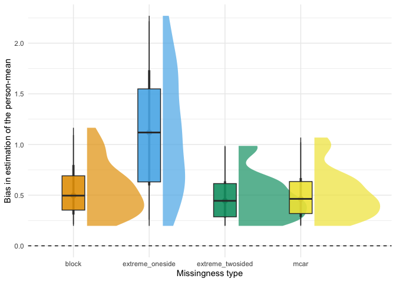

```r
(boxplot_personmean_type = overall_df %>%
  ggplot(aes(x = as.factor(miss_type), y = bias_mean, fill = as.factor(miss_type), group = as.factor(miss_type))) +
  stat_halfeye(justification = -0.2, alpha = 0.7, outlier.size = 1) +
  geom_boxplot(width = 0.3, alpha = 0.9) +
  theme_minimal() +
  scale_fill_manual(values = cbPalette) +
  ylab("Bias in estimation of the person-mean") +
  xlab("Missingness type") +
  theme(legend.position = "none") +
  geom_hline(yintercept = 0, linetype = "dashed")
  )
```

#### Mean compliance

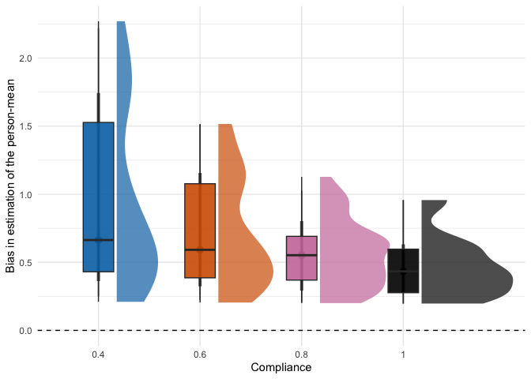

```r
(boxplot_personmean_compliance = overall_df %>%
  ggplot(aes(x = as.factor(comp_mean), y = bias_mean, fill = as.factor(comp_mean), group = as.factor(comp_mean))) +
  stat_halfeye(justification = -0.2, alpha = 0.7, outlier.size = 1) +
  geom_boxplot(width = 0.3, alpha = 0.9) +
  theme_minimal() +
  scale_fill_manual(values = cbPalette_other) +
  ylab("Bias in estimation of the person-mean") +
  xlab("Compliance") +
  theme(legend.position = "none") +
  geom_hline(yintercept = 0, linetype = "dashed")
  )
```

#### Real fixed AR effect

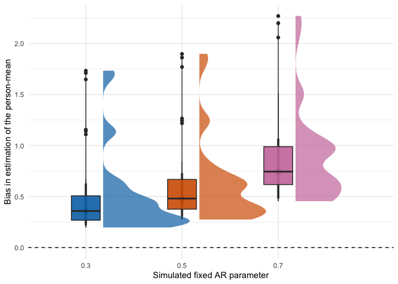

```r
(boxplot_personmean_ar = overall_df %>%
  ggplot(aes(x = as.factor(B1_sim), y = bias_mean, fill = as.factor(B1_sim), group = as.factor(B1_sim))) +
  stat_halfeye(justification = -0.2, alpha = 0.7, outlier.size = 1) +
  geom_boxplot(width = 0.3, alpha = 0.9) +
  theme_minimal() +
  scale_fill_manual(values = cbPalette_other) +
  ylab("Bias in estimation of the person-mean") +
  xlab("Simulated fixed AR parameter") +
  theme(legend.position = "none") +
  geom_hline(yintercept = 0, linetype = "dashed")
  )
```

#### Time-series length

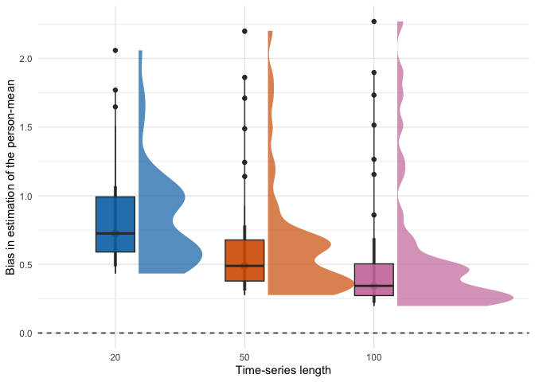

```r
(boxplot_personmean_t = overall_df %>%
  ggplot(aes(x = as.factor(T.obs), y = bias_mean, fill = as.factor(T.obs), group = as.factor(T.obs))) +
  stat_halfeye(justification = -0.2, alpha = 0.7, outlier.size = 1) +
  geom_boxplot(width = 0.3, alpha = 0.9) +
  theme_minimal() +
  scale_fill_manual(values = cbPalette_other) +
  ylab("Bias in estimation of the person-mean") +
  xlab("Time-series length") +
  theme(legend.position = "none") +
  geom_hline(yintercept = 0, linetype = "dashed")
  )
```

#### Interaction: Missingness type * Compliance

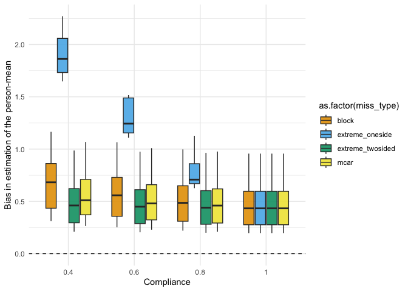

```r
(boxplot_personmean_compliance_misstype = overall_df %>%
  ggplot(aes(x = as.factor(comp_mean), y = bias_mean, fill = as.factor(miss_type))) +
  geom_boxplot(width = 0.7, alpha = 0.9, outlier.size = 1) +
  theme_minimal() +
  scale_fill_manual(values = cbPalette) +
  ylab("Bias in estimation of the person-mean") +
  xlab("Compliance") +
  geom_hline(yintercept = 0, linetype = "dashed")
  )
```

#### Interaction: Missingness type and time-series length

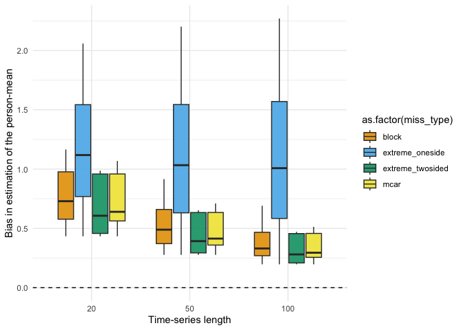

```r
(boxplot_personmean_compliance_misstype = overall_df %>%
  ggplot(aes(x = as.factor(T.obs), y = bias_mean, fill = as.factor(miss_type))) +
  geom_boxplot(width = 0.7, alpha = 0.9, outlier.size = 1) +
  theme_minimal() +
  scale_fill_manual(values = cbPalette) +
  ylab("Bias in estimation of the person-mean") +
  xlab("Time-series length") +
  geom_hline(yintercept = 0, linetype = "dashed")
  )
```

TODO

- correlation between estimation bias and bias in the estimation of
- check assumptions?
- go bayesian?
- compliance and the true fixed AR effect